# Size: 75% POST1 FILTERED L2

## Data analysis

We load the data and remove the cases with NA values.

We have 100 subjects for a total of 1600 observations.

After removal of subjects with POST1 and POST2 <75% and entries with missing data due to wrong answers, we have 86 subjects and 1012 observations left.

We consider the following independent variables: - `LEAYRS` a numerical variable with values ranging from 1 to 16. Learning in years. - `LEA` a percentage scaled to lay between 0 and 10. It indicates the novelty of target construction, measured by subtracting pretest score from posttestscore (POST1-PRE). This value indicates the previous knowledge of construction. - `AMSP` a numerical variable with values ranging from 1 to 5. - `HRSD` a numerical variable with values ranging from 0 to 11.5. L2 use in hours per day.

We rescaled some of these variables to be on similar scales. We treat these as fixed factors under study. In addition we have the random factors described earlier. The same modelling set up applies here.

Our base model is the following `lmm <- lmer(log(Time) ~ type + LEAYRS + LEA + AMSP + HRSD + (1 | List:Name) + (1 | List:type:Order), data = DLM)`

```r
lmm <- lmer(log(Time) ~  type + LEAYRS + LEA + AMSP + HRSD + (1 | List:Name) + (1 | List:type:Order), data = DLM, REML=FALSE)
#summary(lmm)
```

We use a manual, step-forward procedure with likelihood ratio test to see which of the fixed effects are significant.

```r
lmm.0 <- lmer(log(Time) ~  (1 | List:Name) + (1 | List:type:Order), data = DLM)

lmm.1 <- update(lmm.0, .~. + type)
anova(lmm.0,lmm.1)
```

```
## refitting model(s) with ML (instead of REML)
```

```
## Data: DLM
## Models:
## lmm.0: log(Time) ~ (1 | List:Name) + (1 | List:type:Order)
## lmm.1: log(Time) ~ (1 | List:Name) + (1 | List:type:Order) + type
##       Df  AIC  BIC logLik deviance Chisq Chi Df Pr(>Chisq)
## lmm.0  4 1252 1272   -622     1244
## lmm.1  5 1251 1276   -621     1241  2.93      1      0.087 .
## ---
## Signif. codes:  0 '***' 0.001 '**' 0.01 '*' 0.05 '.' 0.1 ' ' 1
```

```r
lmm.2 <- update(lmm.0, .~.+LEAYRS)
anova(lmm.0,lmm.2)
```

```
## refitting model(s) with ML (instead of REML)
```

```
## Data: DLM
## Models:
## lmm.0: log(Time) ~ (1 | List:Name) + (1 | List:type:Order)
## lmm.2: log(Time) ~ (1 | List:Name) + (1 | List:type:Order) + LEAYRS
##       Df  AIC  BIC logLik deviance Chisq Chi Df Pr(>Chisq)
## lmm.0  4 1252 1272   -622     1244
## lmm.2  5 1254 1279   -622     1244  0.16      1       0.69
```

```r
lmm.3 <- update(lmm.0, .~. + LEA)
anova(lmm.0,lmm.3)
```

```
## refitting model(s) with ML (instead of REML)
```

```
## Data: DLM
## Models:
## lmm.0: log(Time) ~ (1 | List:Name) + (1 | List:type:Order)
## lmm.3: log(Time) ~ (1 | List:Name) + (1 | List:type:Order) + LEA
##       Df  AIC  BIC logLik deviance Chisq Chi Df Pr(>Chisq)
## lmm.0  4 1252 1272   -622     1244
## lmm.3  5 1254 1278   -622     1244  0.89      1       0.35
```

```r
lmm.4 <- update(lmm.0, .~. + AMSP)
anova(lmm.0,lmm.4)
```

```
## refitting model(s) with ML (instead of REML)
```

```
## Data: DLM
## Models:
## lmm.0: log(Time) ~ (1 | List:Name) + (1 | List:type:Order)
## lmm.4: log(Time) ~ (1 | List:Name) + (1 | List:type:Order) + AMSP
##       Df  AIC  BIC logLik deviance Chisq Chi Df Pr(>Chisq)
## lmm.0  4 1252 1272   -622     1244
## lmm.4  5 1245 1269   -617     1235   9.8      1     0.0017 **
## ---
## Signif. codes:  0 '***' 0.001 '**' 0.01 '*' 0.05 '.' 0.1 ' ' 1
```

```r
lmm.5 <- update(lmm.0, .~. + HRSD)
anova(lmm.0,lmm.5)
```

```
## refitting model(s) with ML (instead of REML)
```

```
## Data: DLM
## Models:
## lmm.0: log(Time) ~ (1 | List:Name) + (1 | List:type:Order)
## lmm.5: log(Time) ~ (1 | List:Name) + (1 | List:type:Order) + HRSD
##       Df  AIC  BIC logLik deviance Chisq Chi Df Pr(>Chisq)
## lmm.0  4 1252 1272   -622     1244
## lmm.5  5 1252 1277   -621     1242  2.48      1       0.12
```

We conclude that only `AMSP` has a significant effect at a 0.05 level while `type` is significant at a 0.1 level.

An automatic, step-backward procedure from the package lmerTest starting from a model that includes all second order fixed factor intereactions lead to a similar conclusion: only the factor `AMSP` is kept in the model.

```r
require(lmerTest)
lmm.6 <- lmer(log(Time) ~ (type + LEAYRS + LEA + AMSP + HRSD)^2 + (1 | List:Name) + (1 | List:type:Order), data = DLM)
ft<-step(lmm.6)
ft
```

```
##
## Random effects:
##                 Chi.sq Chi.DF elim.num p.value
## List:Name       203.26      1     kept < 1e-07
## List:type:Order  89.03      1     kept < 1e-07
##
## Fixed effects:
##             Sum Sq Mean Sq NumDF  DenDF F.value elim.num Pr(>F)
## LEA:HRSD    0.0082  0.0082     1  74.11  0.0507        1 0.8225
## LEA:AMSP    0.0631  0.0631     1  75.16  0.3902        2 0.5341
## LEAYRS:LEA  0.0588  0.0588     1  76.73  0.3635        3 0.5483
## type:HRSD   0.0863  0.0863     1 902.67  0.5333        4 0.4654
## type:AMSP   0.0629  0.0629     1 921.23  0.3890        5 0.5330
## type:LEAYRS 0.0744  0.0744     1 905.77  0.4604        6 0.4976
## AMSP:HRSD   0.1121  0.1121     1  78.37  0.6941        7 0.4073
## LEAYRS:HRSD 0.0502  0.0502     1  75.74  0.3110        8 0.5787
## HRSD        0.1103  0.1103     1  77.98  0.6826        9 0.4112
## type:LEA    0.1766  0.1766     1 908.16  1.0933       10 0.2960
## LEA         0.0003  0.0003     1  80.56  0.0017       11 0.9672
## LEAYRS:AMSP 0.2334  0.2334     1  83.88  1.4445       12 0.2328
## LEAYRS      0.2194  0.2194     1  82.14  1.3580       13 0.2472
## type        0.4735  0.4735     1  30.69  2.9302       14 0.0970
## AMSP        1.6420  1.6420     1  85.72 10.1598     kept 0.0020
##
## Least squares means:
##      Estimate Standard Error DF t-value Lower CI Upper CI p-value
##
##  Differences of LSMEANS:
##      Estimate Standard Error DF t-value Lower CI Upper CI p-value
##
## Final model:
## lme4::lmer(formula = log(Time) ~ AMSP + (1 | List:Name) + (1 |
##     List:type:Order), data = DLM, REML = reml.lmerTest.private,
##     contrasts = l.lmerTest.private.contrast, devFunOnly = devFunOnly.lmerTest.private)
```

```r
summary(ft$model)
```

```
## Linear mixed model fit by REML t-tests use Satterthwaite
##   approximations to degrees of freedom [lmerMod]
## Formula: log(Time) ~ AMSP + (1 | List:Name) + (1 | List:type:Order)
##    Data: DLM
##
## REML criterion at convergence: 1243.2
##
## Scaled residuals:
##    Min     1Q Median     3Q    Max
## -3.178 -0.659 -0.119  0.580  4.246
##
## Random effects:
##  Groups          Name        Variance Std.Dev.
##  List:Name       (Intercept) 0.0699   0.264
##  List:type:Order (Intercept) 0.0271   0.165
##  Residual                    0.1616   0.402
## Number of obs: 1012, groups:  List:Name, 86; List:type:Order, 32
##
## Fixed effects:
##             Estimate Std. Error      df t value Pr(>|t|)
## (Intercept)   7.6407     0.2128 89.6000   35.91   <2e-16 ***
## AMSP         -0.1624     0.0509 85.7000   -3.19    0.002 **
## ---
## Signif. codes:  0 '***' 0.001 '**' 0.01 '*' 0.05 '.' 0.1 ' ' 1
##
## Correlation of Fixed Effects:
##      (Intr)
## AMSP -0.979
```

```r
lmm<-ft$model
```

Finally, Analysis of Variance Table of type III with Satterthwaite approximation for degrees of freedom leads to the same conclusions as the likelihood ratio test procedure. It is reported at the end of this document.

The figures show random and the fixed effects. Again the subject effects are significant. We back transformed the fixed effects in linear scale and added 0.95-confidence level bands. It is evident the reduction in reaction time as `AMSP` increases. Although `type` has an effect it is not large.

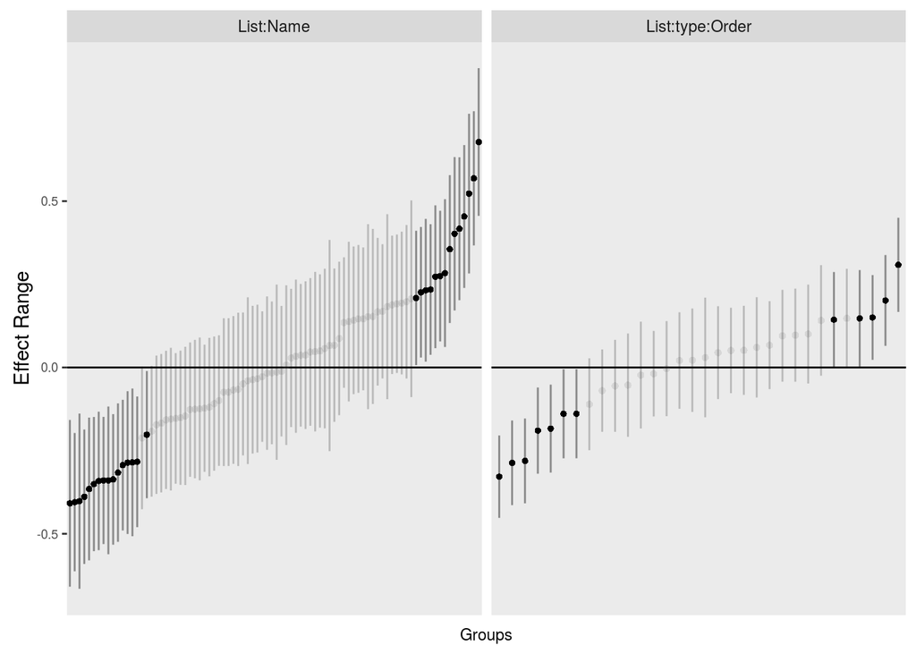

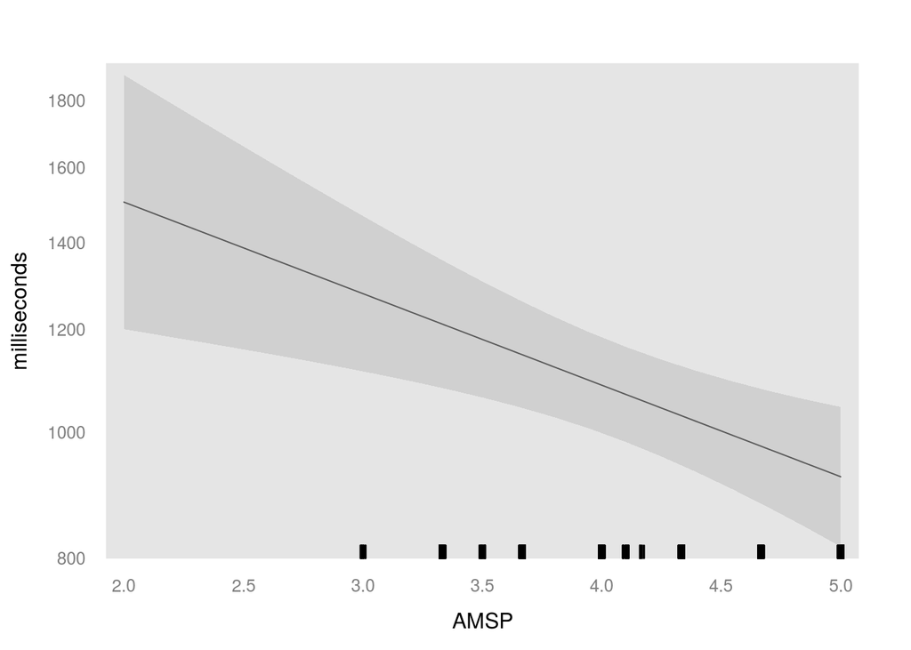

## Diagnostic plots

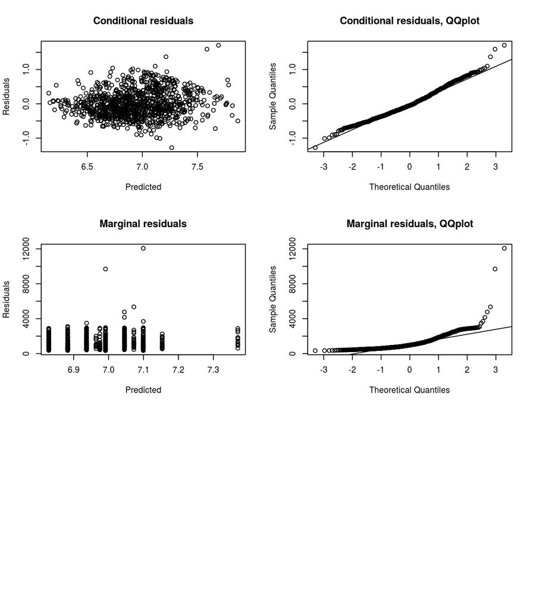

```r
par(mfrow=c(3,2))
# plot(lm4,which=1:4)

plot(fitted(lmm, type = "response"), residuals(lmm, type = "response"),
     main = "Conditional residuals", xlab = "Predicted", ylab = "Residuals")

res <- residuals(lmm, type = "response")
qqnorm(res, main = "Conditional residuals, QQplot")
qqline(res)

#lm.0 <- lm(log(Time) ~ (type + HRSD + LEAYRS + AMSP), data = DLM)
lm.0 <- lm(log(Time) ~ (AMSP), data = DLM)
x <- model.matrix(lm.0)
pred <- x %*% fixef(lmm)
res <- DLM$Time - pred
plot(pred, res, main = "Marginal residuals", xlab = "Predicted", ylab = "Residuals")
qqnorm(res, main = "Marginal residuals, QQplot")
qqline(res)
```

The joint qqplot looks normal. The marginal looks less nice.

## Anova Table with Satterwhite

```r
require(lmerTest)
lmm <- lmer(log(Time) ~  type + LEAYRS + (PRE + POST1)^2 + AMSP + HRSD + POST1*HRSD + (1 | List:Name) + (1 | List:type:Order), data = DLM, REML=FALSE)
anova(lmm)
```

```
## Analysis of Variance Table of type III  with  Satterthwaite
## approximation for degrees of freedom
##            Sum Sq Mean Sq NumDF DenDF F.value Pr(>F)
## type        0.503   0.503     1  32.7    3.12 0.0869 .
## LEAYRS      0.314   0.314     1  85.3    1.94 0.1672
## PRE         0.408   0.408     1  85.0    2.53 0.1158
## POST1       0.099   0.099     1  84.9    0.61 0.4369
## AMSP        1.780   1.780     1  90.1   11.01 0.0013 **
## HRSD        0.458   0.458     1  85.5    2.83 0.0961 .
## PRE:POST1   0.406   0.406     1  85.0    2.51 0.1167
## POST1:HRSD  0.470   0.470     1  85.5    2.91 0.0917 .
## ---
## Signif. codes:  0 '***' 0.001 '**' 0.01 '*' 0.05 '.' 0.1 ' ' 1
```

```r
summary(lmm)
```

```
## Linear mixed model fit by maximum likelihood t-tests use
##   Satterthwaite approximations to degrees of freedom [lmerMod]
## Formula:
## log(Time) ~ type + LEAYRS + (PRE + POST1)^2 + AMSP + HRSD + POST1 *
##     HRSD + (1 | List:Name) + (1 | List:type:Order)
##    Data: DLM
##
##      AIC      BIC   logLik deviance df.resid
##   1249.1   1308.2   -612.6   1225.1     1000
##
## Scaled residuals:
##    Min     1Q Median     3Q    Max
## -3.191 -0.659 -0.115  0.586  4.333
##
## Random effects:
##  Groups          Name        Variance Std.Dev.
##  List:Name       (Intercept) 0.0628   0.251
##  List:type:Order (Intercept) 0.0234   0.153
##  Residual                    0.1616   0.402
## Number of obs: 1012, groups:  List:Name, 86; List:type:Order, 32
##
## Fixed effects:
##              Estimate Std. Error       df t value Pr(>|t|)
## (Intercept)   9.06971    1.81012 84.80000    5.01  2.9e-06 ***
## typeMISMATCH  0.10624    0.06019 32.70000    1.76   0.0869 .
## LEAYRS        0.01169    0.00839 85.30000    1.39   0.1672
## PRE          -0.45310    0.28514 85.00000   -1.59   0.1158
## POST1        -0.14449    0.18498 84.90000   -0.78   0.4369
## AMSP         -0.18419    0.05550 90.10000   -3.32   0.0013 **
## HRSD          2.41534    1.43525 85.50000    1.68   0.0961 .
## PRE:POST1     0.04589    0.02895 85.00000    1.58   0.1167
## POST1:HRSD   -0.24658    0.14458 85.50000   -1.71   0.0917 .
## ---
## Signif. codes:  0 '***' 0.001 '**' 0.01 '*' 0.05 '.' 0.1 ' ' 1
##
## Correlation of Fixed Effects:
##             (Intr) tMISMA LEAYRS PRE    POST1  AMSP   HRSD   PRE:PO
## typMISMATCH -0.012
## LEAYRS       0.009 -0.005
## PRE         -0.840 -0.008 -0.074
## POST1       -0.992 -0.004  0.003  0.825
## AMSP        -0.090 -0.006 -0.226  0.104 -0.011
## HRSD        -0.112  0.003  0.102 -0.233  0.124 -0.125
## PRE:POST1    0.845  0.008  0.070 -0.999 -0.832 -0.117  0.231
## POST1:HRSD   0.113 -0.003 -0.101  0.233 -0.125  0.121 -1.000 -0.231
```